# Reproducible Research: Peer Assessment 1

```r
echo = TRUE  # visible code chunks
options(scipen = 1)  # Turn off scientific notations for numbers
```

## Loading and preprocessing the data

```r
unzip(zipfile = "activity.zip")
data <- read.csv("activity.csv")
```

## What is mean total number of steps taken per day?

1.Make a histogram of the total number of steps taken each day

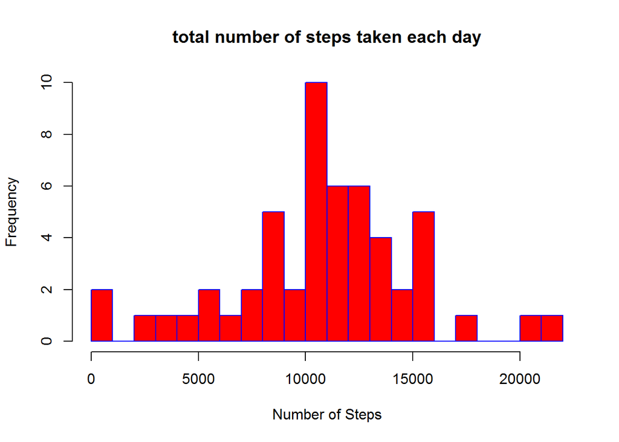

```r
steps_by_date <- aggregate(steps ~ date, data, sum)
hist(steps_by_date$steps, main = paste("total number of steps taken each day"), col=I("red"),border="blue",   breaks=30, xlab="Number of Steps")
```

2.Calculate and report the **mean** and **median** total number of steps taken per day

```r
mean_steps <- mean(steps_by_date$steps)
```

mean is :10766

```r
median_steps <- median(steps_by_date$steps)
```

and median is : 10765

## What is the average daily activity pattern?

calculate average number of steps per day aggregated by interval:

```r
steps_by_interval <- aggregate(steps ~ interval, data, mean)
```

Use plot for making the time series of the 5-minute interval and average steps taken:

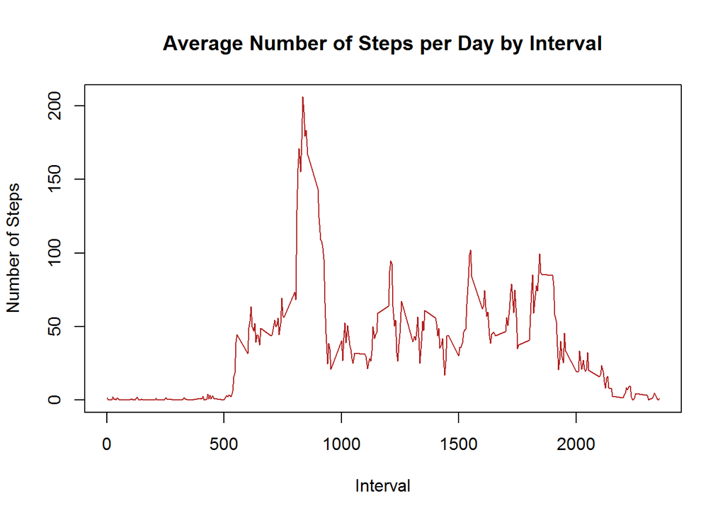

```r
plot(steps_by_interval$interval,steps_by_interval$steps, type="l", xlab="Interval", col = "firebrick", ylab="Number of Steps",main="Average Number of Steps per Day by Interval")
```

Which 5-minute interval, on average across all the days in the dataset, contains the maximum number of steps?

```r
max_interval <- steps_by_interval[which.max(steps_by_interval$steps),1]
```

The 5-minute interval, on average across all the days, containing the maximum number of steps is : 835